# Quality of training - Practical ML course project

Max Dunaevsky

5/19/2019

# Data preparation

## Loading libraries

```r
library(ggplot2)
library(lattice)
library(caret)
library(rpart)
library(rpart.plot)
library(randomForest)
library(data.table)
library(e1071)
library (xgboost)
library(gbm)
library(C50)
```

## Loading data

```r
url_to_train_set <- "https://d396qusza40orc.cloudfront.net/predmachlearn/pml-training.csv"
url_to_test_set <- "https://d396qusza40orc.cloudfront.net/predmachlearn/pml-testing.csv"

train_set_init <- fread(url_to_train_set)
test_set <- fread(url_to_test_set)
```

## Splitting out train and validation dataset(to asses expected out of sample error)

```r
set.seed(777)
inTrain <- createDataPartition(y=train_set_init$classe, p=0.6, list=FALSE)
train_set <- train_set_init[inTrain, ]
validation_set <- train_set_init[-inTrain, ]
```

## Eliminating variables with near zero variance

Will orient on variance in test set because many obs from that set have only NAs.

```r
myDataNZV <- nearZeroVar(test_set, saveMetrics=FALSE, names = TRUE)
```

More than 100 such vars. Using this variables won’t be helpful in prediction.

## Selecting features to use

```r
selected_columns <- setdiff(names(train_set),myDataNZV)
train_set <- train_set[,..selected_columns]
```

## Inputting mean values instead of NAs so as not to lose some useful information in data

```r
for (i in names(train_set)){
  train_set[,(i) := ifelse(is.na(get(i)),mean(get(i),na.rm = TRUE),get(i))]
}
```

## Classes distribution.

There is no extremely large skewness in classes distribution therefore will use accuracy as our main metric when training models.

```r
percentage <- prop.table(table(train_set$classe))*100
cbind(freq = table(train_set$classe), percentage = percentage)
```

```
##   freq percentage
## A 3348   28.43071
## B 2279   19.35292
## C 2054   17.44226
## D 1930   16.38927
## E 2165   18.38485
```

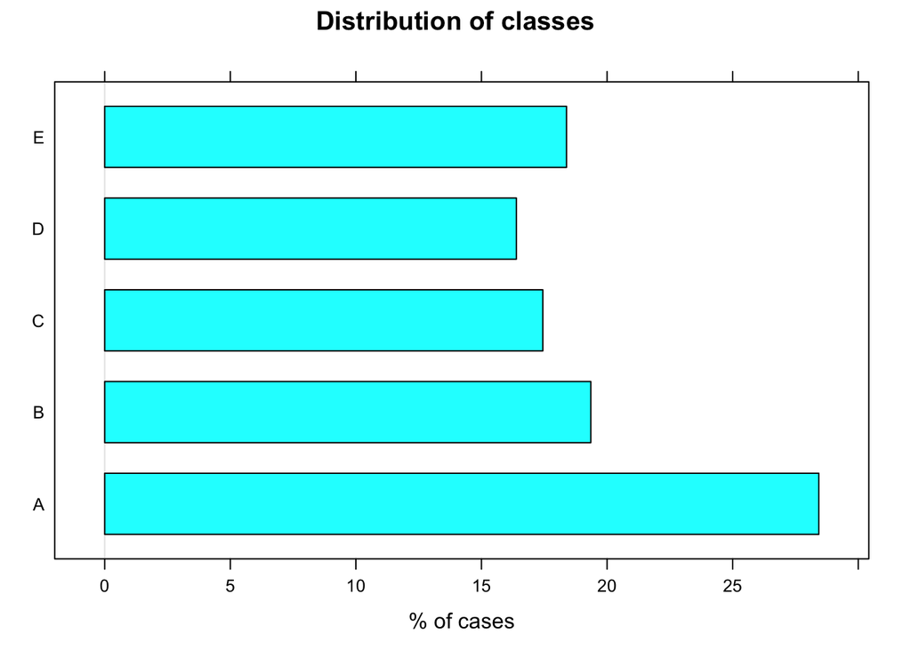

```r
barchart(percentage, xlab = "% of cases", main = "Distribution of classes")
```

## Multicolinearity check

Removing vars that could cause sporadic correlation but in fact is not at all logically related to classe value.

```r
meaningful_columns <- setdiff(names(train_set), c("V1", "user_name", "cvtd_timestamp", "raw_timestamp_part_1", "raw_timestamp_part_2"))
train_set <- train_set[,..meaningful_columns]
```

Determining highly correlated variables.

```r
cor_selected_columns <- setdiff(names(train_set), "classe")
correlations <- cor(train_set[,..cor_selected_columns])
highlyCorrelated <- findCorrelation(correlations, cutoff = 0.7)
high_cor_columns_to_exclude <- cor_selected_columns[highlyCorrelated]
```

Following columns will be excluded from further analysis.

```r
high_cor_columns_to_exclude
```

```
##  [1] "accel_belt_z"      "roll_belt"         "accel_belt_y"
##  [4] "total_accel_belt"  "yaw_belt"          "accel_dumbbell_z"
##  [7] "accel_belt_x"      "pitch_belt"        "magnet_dumbbell_x"
## [10] "accel_dumbbell_y"  "magnet_dumbbell_y" "accel_arm_x"
## [13] "accel_dumbbell_x"  "accel_arm_z"       "magnet_arm_y"
## [16] "magnet_belt_z"     "accel_forearm_y"   "gyros_forearm_y"
## [19] "gyros_dumbbell_x"  "gyros_dumbbell_z"  "gyros_arm_x"
```

Excluding highly correlated columns

```r
selected_cols_after_cor <- setdiff(names(train_set),high_cor_columns_to_exclude)
train_set <- train_set[, ..selected_cols_after_cor]
```

## PCA analysis

Shows that we really need not so much vars to capture 80% of variables’ variance

```r
procTrain <- preProcess(train_set, method = "pca", thresh = 0.8 )
procTrain
```

```
## Created from 11776 samples and 33 variables
##
## Pre-processing:
##   - centered (32)
##   - ignored (1)
##   - principal component signal extraction (32)
##   - scaled (32)
##
## PCA needed 14 components to capture 80 percent of the variance
```

## Same data preprocessing with validation dataset

```r
validation_set <- validation_set[,..selected_cols_after_cor]
for (i in names(validation_set)){
  validation_set[,(i) := ifelse(is.na(get(i)),mean(get(i),na.rm = TRUE),get(i))]
}
```

# Building models

First of all let’s build simple tree model to get understanding of possible levels of accuracy and have some nice visual representation explaining why model predicts one or other value.

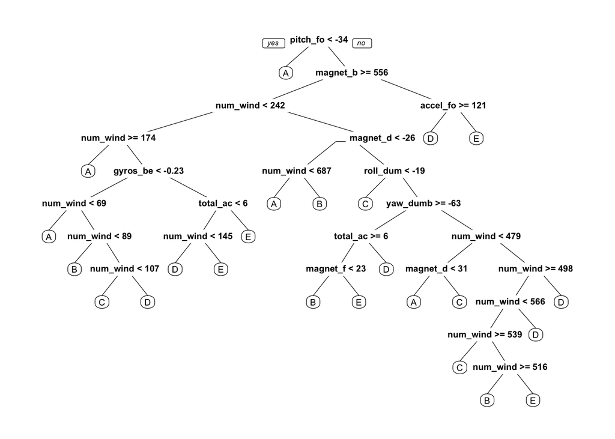

```r
set.seed(777)
d_tree_model <- rpart(classe ~ ., data = train_set, method = "class")
prp(d_tree_model)
```

## Estimating expected out of sample error

For this basic model accuracy is lower than - 80%.

```r
pred_valid_set <- predict(d_tree_model, validation_set, type = "class")
confusionMatrix(pred_valid_set, as.factor(validation_set$classe))
```

```
## Confusion Matrix and Statistics
##
##           Reference
## Prediction    A    B    C    D    E
##          A 1950  113    2   16   37
##          B  122 1068  116  186  147
##          C   30  163 1132   64    9
##          D  127  108  117  967  258
##          E    3   66    1   53  991
##
## Overall Statistics
##
##                Accuracy : 0.7785
##                  95% CI : (0.7691, 0.7876)
##     No Information Rate : 0.2845
##     P-Value [Acc > NIR] : < 2.2e-16
##
##                   Kappa : 0.7206
##  Mcnemar's Test P-Value : < 2.2e-16
##
## Statistics by Class:
##
##                      Class: A Class: B Class: C Class: D Class: E
## Sensitivity            0.8737   0.7036   0.8275   0.7519   0.6872
## Specificity            0.9701   0.9098   0.9589   0.9070   0.9808
## Pos Pred Value         0.9207   0.6516   0.8097   0.6132   0.8896
## Neg Pred Value         0.9508   0.9275   0.9634   0.9491   0.9330
## Prevalence             0.2845   0.1935   0.1744   0.1639   0.1838
## Detection Rate         0.2485   0.1361   0.1443   0.1232   0.1263
## Detection Prevalence   0.2699   0.2089   0.1782   0.2010   0.1420
## Balanced Accuracy      0.9219   0.8067   0.8932   0.8295   0.8340
```

## Using caret package to train a set of models

Settings for accuracy oriented optimization. Also setting crossvalidation as our train method.

```r
metric <- "Accuracy"
trainControl <- trainControl(method="cv", number=3)
```

LDA model:

```r
set.seed(777)
fit.lda <- train(classe ~ ., data = train_set, method = "lda",
                 metric = metric, trControl = trainControl)
```

CART model:

```r
set.seed(777)
fit.cart <- train(classe ~ ., data = train_set, method = "rpart",
                  metric = metric, trControl = trainControl)
```

Random Forest model:

```r
set.seed(777)
fit.rf <- train(classe ~ ., data = train_set, method = "rf",
                metric = metric, trControl = trainControl)
```

Stochastic Gradient Boosting model:

```r
set.seed(777)
fit.gbm <- train(classe ~ ., data = train_set, method = "gbm",
                 metric = metric, trControl = trainControl, verbose = FALSE,
                 preProcess = c("center", "scale"))
```

C5.0 model:

```r
set.seed(777)
fit.c50 <- train(classe ~ ., data = train_set, method="C5.0", metric=metric,
                 trControl=trainControl)
```

XGBoost model: Here also setting some tuning params from results of previous runs.

```r
grid <- expand.grid(
  .nrounds = 150,
  .max_depth = 3,
  .eta=0.3,
  .gamma = 0,
  .colsample_bytree=c(0.8),
  .min_child_weight = 1,
  .subsample =1)
fit.xgboost <- train(classe ~ ., data = train_set, method="xgbTree", metric=metric, trControl=trainControl, tuneGrid = grid)
```

# Comparing models

XGBoost model seems to be most promising one given almost 100% accuracy.

```r
results = resamples(list(CART = fit.cart, LDA = fit.lda, RF = fit.rf, GBM = fit.gbm,
                         XGBoost = fit.xgboost, C50 = fit.c50))
summary(results)
```

```
##
## Call:
## summary.resamples(object = results)
##
## Models: CART, LDA, RF, GBM, XGBoost, C50
## Number of resamples: 3
##
## Accuracy
##              Min.   1st Qu.    Median      Mean   3rd Qu.      Max. NA's
## CART    0.4915902 0.5104411 0.5292919 0.5249604 0.5416454 0.5539990    0
## LDA     0.6016302 0.6054787 0.6093272 0.6088656 0.6124833 0.6156393    0
## RF      0.9923586 0.9928664 0.9933741 0.9935462 0.9941399 0.9949058    0
## GBM     0.9824249 0.9825478 0.9826707 0.9838653 0.9845855 0.9865003    0
## XGBoost 0.9979623 0.9983440 0.9987258 0.9985564 0.9988535 0.9989812    0
## C50     0.9961793 0.9969429 0.9977064 0.9976223 0.9983438 0.9989812    0
##
## Kappa
##              Min.   1st Qu.    Median      Mean   3rd Qu.      Max. NA's
## CART    0.3481772 0.3691767 0.3901763 0.3880963 0.4080558 0.4259353    0
## LDA     0.4964346 0.5010090 0.5055835 0.5049623 0.5092262 0.5128689    0
## RF      0.9903343 0.9909765 0.9916187 0.9918364 0.9925874 0.9935561    0
## GBM     0.9777698 0.9779259 0.9780820 0.9795912 0.9805019 0.9829217    0
## XGBoost 0.9974227 0.9979055 0.9983883 0.9981741 0.9985498 0.9987114    0
## C50     0.9951673 0.9961332 0.9970990 0.9969926 0.9979052 0.9987114    0
```

# Estimating expected out of sample error of selected XGBoost model

As we see even out of sample error is quite low which is a great news.

```r
pred_valid_set <- predict(fit.xgboost, validation_set, type = "raw")
confusionMatrix(pred_valid_set, as.factor(validation_set$classe))
```

```
## Confusion Matrix and Statistics
##
##           Reference
## Prediction    A    B    C    D    E
##          A 2232    1    0    0    0
##          B    0 1517    0    0    0
##          C    0    0 1367    0    0
##          D    0    0    1 1286    0
##          E    0    0    0    0 1442
##
## Overall Statistics
##
##                Accuracy : 0.9997
##                  95% CI : (0.9991, 1)
##     No Information Rate : 0.2845
##     P-Value [Acc > NIR] : < 2.2e-16
##
##                   Kappa : 0.9997
##  Mcnemar's Test P-Value : NA
##
## Statistics by Class:
##
##                      Class: A Class: B Class: C Class: D Class: E
## Sensitivity            1.0000   0.9993   0.9993   1.0000   1.0000
## Specificity            0.9998   1.0000   1.0000   0.9998   1.0000
## Pos Pred Value         0.9996   1.0000   1.0000   0.9992   1.0000
## Neg Pred Value         1.0000   0.9998   0.9998   1.0000   1.0000
## Prevalence             0.2845   0.1935   0.1744   0.1639   0.1838
## Detection Rate         0.2845   0.1933   0.1742   0.1639   0.1838
## Detection Prevalence   0.2846   0.1933   0.1742   0.1640   0.1838
## Balanced Accuracy      0.9999   0.9997   0.9996   0.9999   1.0000
```

# Prediction on test set

## Preprocessing data like train_set

```r
test_selected_columns <- setdiff(names(train_set), "classe")
test_set <- test_set[,..test_selected_columns]
for (i in names(test_set)){
  test_set[,(i) := ifelse(is.na(get(i)),mean(get(i),na.rm = TRUE),get(i))]
}
```

## Prediction itself

```r
pred_test_set <- predict(fit.xgboost, test_set, type = "raw")
```